# Crime and Academic Success: An Econometric Study in NYC Schools

Will Ackerman and Brendan Monohan

2024-12-13

# Abstract

# Introduction

Educational outcomes remain a critical area of research due to their profound social and political implications. Public school students in America often face disparities in access to quality education, influenced by factors beyond their control, such as neighborhood crime rates, income inequality, and socioeconomic conditions. These external forces shape academic success, perpetuating systemic inequities which challenge the notion of equal opportunity as a societal cornerstone. This research seeks to investigate how such factors influence educational outcomes and highlight the gap between the ideals of equity and the lived experiences of many communities.

The interplay between academic achievement and external factors such as crime, family income, and neighborhood economic status has been a subject of extensive research. This raises the critical question: How does neighborhood socioeconomic status, as reflected by local crime rates, influence school-level academic performance in the New York City public school system, while controlling for other socioeconomic factors?

[interactive chart not shown]

The New York City public school system provides an ideal case study for examining these questions due to its robust data availability from 2015 to 2018 and its relevance in national education debates. Of particular interest is the 2016 New York State Crime Reform Act, which aimed to reduce court summons for minor offenses and redirect judicial focus to more significant crimes. This reform resulted in a substantial decline in arrests across New York, raising questions about its broader implications for students and their academic performance. This study investigates whether the Crime Reform Act influenced educational outcomes and explores the relationships between neighborhood crime, property values, and school success within the NYC public school system. Building upon prior studies that have explored the connections between socio-economic factors and educational outcomes, this research seeks to expand the understanding of these dynamics by incorporating neighborhood crime, property values, and student safety into the analysis. By contextualizing these variables within the framework of the New York City public school system, this study aims to complement existing literature while providing a more comprehensive perspective on the systemic barriers to educational equity.

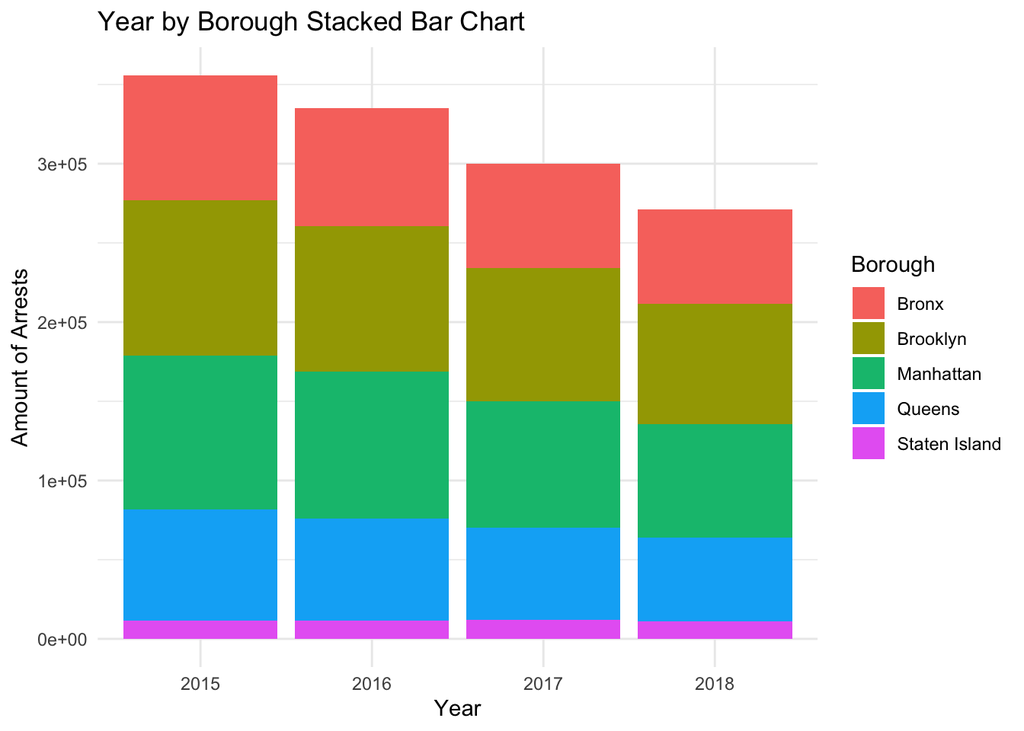

## Working Papers of the Past

The relationship between school resources, socioeconomic status (SES), and academic performance remains a pivotal focus in educational policy research. Numerous studies have highlighted how disparities in SES and localized crime shape students’ educational experiences and overall school performance. This paper draws inspiration from existing literature, including the influential research by E. Jason Baron, Joshua M. Hyman, and Brittany M. Vasquez, which examines the intricate connections between public school funding, school quality, and adult crime. The authors frame their study with a compelling question: “Could increasing public school funding be an effective long-run crime-prevention strategy? Moreover, does the answer depend on the type of funding—for example, operating versus capital (Baron)?” The study utilizes data from Michigan to reveal that a 10% increase in annual operating expenditures for students from Kindergarten through third grade correlates with a 15% reduction in the likelihood of committing a crime by the age of 30. Second, the study explores the impact of school quality improvements, including measures such as reducing class sizes, decreasing teacher turnover, increasing teacher salaries and experience, and hiring additional school leadership to maintain school discipline. However, these initiatives, examined as part of a second proposal within the study, show an insignificant correlation with reductions in adult crime. Overall, the findings suggest that increased funding, rather than school quality improvements alone, plays a more significant role in reducing the percentage of students who commit crimes by the age of 30.

Interestingly, while academic performance between treated and non-treated students showed no significant differences, behavioral outcomes revealed notable improvements. Treated students demonstrated lower absenteeism, reduced likelihood of juvenile detention, and higher rates of high school graduation and college degree attainment. The researchers identified close political elections as a causal driver of increased school expenditures. Their analysis revealed that, on average, school expenditures rose by 20% following tightly contested elections. This increase in funding led to a long-term reduction in adult crime among students at the affected schools. To identify such instances, the researchers analyzed historical data to pinpoint locations with close elections and cross-referenced these with school-level crime and performance data. Their findings revealed that schools receiving increased public funding in these areas experienced slightly higher test scores and attendance rates, alongside lower adult crime rates. Additionally, the study highlighted a troubling trend: low-income and low-performing school districts consistently exhibited lower public school expenditures and higher crime rates.

In addition, David J. Deming’s working paper explores the relationship between school quality and the prevalence of crime within and around schools, examining whether improved public education can serve as a crime prevention tool. Previous studies have established a negative relationship between crime and school quality. For instance, Lochner (2004) finds that as students experience fewer years of education, crime rates tend to increase. Building on these findings, Deming focuses on the specific impact of school quality on crime rates, rather than the broader effects of educational attainment. His methodology links data from the Charlotte-Mecklenburg school district in North Carolina with arrest and incarceration records from Mecklenburg County. A key component of his study is the use of school lotteries, which allowed students to apply to their preferred schools. Deming uses lottery selection as an independent variable to isolate the effects of attending a higher-quality school. His findings reveal that students who attend their first-choice schools through the lottery tend to have lower crime rates as adults, underscoring the potential of school choice to influence long-term outcomes.

Deming further observes that high-risk youth attending their first-choice schools commit 50% fewer crimes than their peers. These significant differences in crime rates highlight the critical role school quality plays, with higher-quality schools consistently associated with lower crime rates. Even a treatment of just 1–4 years of enrollment in a first choice school is enough to demonstrate the impact of school quality on reducing criminal behavior. Deming’s analysis also draws a fascinating distinction between middle and high school students: middle schoolers are primarily influenced by their peers and immediate surroundings, while high schoolers are more significantly shaped by the quality of their schools and teachers. While Deming focuses on the relationship between school quality and crime, our study shifts the focus to explore how crime rates correlates with academic performance, providing a different perspective on the interplay between education and safety.

Another study explores the impact of race on school quality, shedding light on persistent social discrimination even after the 1964 Civil Rights Act. The researchers find that low-income Black children face significant disadvantages in accessing high-quality education and highlight a strong correlation between mean residential income and academic performance. Similar to Deming’s work, this study examines whether high-quality schools can disrupt cycles of intergenerational poverty. One proposed approach involves maintaining consistent school quality while varying neighborhood conditions to assess their independent effects. To analyze these dynamics, the authors employ a production function to estimate academic performance, adding a structured lens to their investigation;
$$\text{Outcome}_{j} = f_{j}(\eta, \sigma, \phi),$$
“Where $\eta$ represents neighborhood quality, $\sigma$ denotes school quality, and $\phi$ captures family background. We assume that $f$ is smooth and twice continuously differentiable in its arguments (Fryer 233).” This framework is used in the Moving To Opportunity (MTO) program. This program provides housing vouchers to low-income families to improve educational opportunities, reduce economic disparities between the rich and poor, and decrease the number of individuals who resort to criminal activity during times of financial distress. Fryer and Katz studied households participating in this program as the treatment group. While neighborhood quality improved due to the housing vouchers, school quality remained unchanged. The poverty rates in the neighborhoods experienced a notable reduction, starting from an initial level of 53%, which decreased by 9 percentage points over a span of 10 to 15 years. Despite this improvement in living conditions, academic performance showed only modest gains. Students in schools who received housing vouchers achieved average state test scores that were 3% higher than their peers without vouchers, highlighting a limited impact on educational outcomes.

A notable outcome of the MTO program was the significant improvement in adult female mental health, irrespective of changes in neighborhood or school quality. However, other factors, such as academic achievement, educational attainment, risky behaviors, or labor market outcomes, showed no measurable changes. The study also drew comparisons to similar experiments, such as STARR, which demonstrated that students randomly assigned to smaller class sizes at a young age achieved higher rates of educational attainment. Another study, conducted by Chetty, Friedman, and Rockoff, found that students randomly assigned to high-value (HV) teachers were more likely to attend college and avoid teen pregnancy. Similarly, the Harlem Children’s Zone (HCZ) revealed that students admitted through a lottery to the Promise Academy Charter School exhibited improved math scores, slight reading gains, a 14% higher likelihood of college enrollment, and a 4.3% lower chance of incarceration.

These HCZ findings stand in contrast to the limited academic impacts observed in the MTO program. The MTO study by Fryer and Katz concluded that neighborhood quality improvements primarily benefited mental health, while school quality enhancements more effectively addressed economic disparities. While this research draws significant insights from the MTO analysis, it aligns more closely with HCZ findings in observing that specific factors, such as crime, play a pivotal role in shaping academic success rather than broader variables like general neighborhood quality.

The working paper by Linda M. Ruiz, Susan D. McMahon, and Leonard A. Jason examines the intricate relationships between socioeconomic status (SES), neighborhood demographics, and school quality, while also exploring how school climate can influence academic performance. In theory, academic success serves as a predictor of educational attainment, employment quality, and future earnings. While this study aligns with previously discussed research, it uniquely emphasizes the role of school climate in shaping overall academic outcomes.

Earlier studies, such as those by Orfield, Kucsera, and Siegel-Hawley (2012) and Sirin (2005), highlight how neighborhood characteristics shape school performance. This paper builds on three foundational theories: Bronfenbrenner’s Social Ecological Model, which underscores the adverse impact of neighborhood disadvantages on youth academic outcomes; McKay’s Social Disorganization Theory, which links neighborhood disadvantages like poverty, low employment, and low educational attainment to crime; and Resilience Theory (Luthar & Cicchetti, 2000), which suggests that disadvantaged students can overcome adversity to achieve higher educational success.

The study highlights that students living in low-income neighborhoods with high crime exposure tend to experience significantly lower levels of academic achievement. Building on established theoretical frameworks, the researchers hypothesize a positive correlation between socioeconomic status (SES) and academic performance, mediated by the influence of violent crime. Specifically, they propose that SES will be negatively associated with violent crime, which, in turn, will be negatively correlated with academic achievement. Additionally, the study posits that a lack of school safety will further compound these challenges, directly impacting academic outcomes.

The study’s methodology centers on elementary schools within the Chicago Public Schools (CPS) system, which often select students based on household location. From a total of 483 schools, a sample of 288 was selected for analysis. To measure academic achievement, the researchers employed a hedonic model incorporating variables such as income, education, employment, socioeconomic status (SES), violent crime, school safety, academic performance, and school climate. The study utilized GIS (Geographic Information Systems) to analyze spatial relationships between variables such as SES, violent crime, and academic achievement. By layering these variables in a geospatial framework, the researchers visualized patterns and explored associations based on location. This approach enabled the development of maps for each variable, facilitating comparisons to identify correlations with academic achievement. The findings demonstrated that crime is a significant predictor of both socioeconomic status and academic outcomes, ultimately supporting the hypotheses outlined in the study. Furthermore, the working paper by Ruiz et al. served as a central inspiration for this research question. Building on their approach, this study seeks to extend the understanding of these dynamics by focusing on public schools in New York City.

There are many parallels from which the working paper above draws distinctions. Fortunately, there are plenty of discussions and academic studies that provide an influential framework for continued exploitation of the subject The papers outlined above find that crime does affect school outcomes but is never the sole or main variable of interest. The variables used in the studies above are:

- **Socioeconomic Status (SES):** Examines the role of family income, neighborhood characteristics, and parental education in shaping students’ academic outcomes.
- **School Quality:** Investigates the effects of teacher experience, class size, school resources, and overall learning environment on student performance.
- **Public School Funding:** Explores the relationship between financial investments in schools and their impact on graduation rates, standardized test scores, and long-term economic benefits.
- **Crime in and out of School:** Analyzes how crime rates within and around school premises influence attendance, safety perceptions, and academic success.
- **The Impact of School Lotteries:** Evaluates the effect of randomized school assignments on equity, access to quality education, and student achievement.
- **The Impacts of Local Government Elections on Academic Success:** Studies how political decisions and changes in local governance influence educational policies and school funding allocations.

The working paper focuses explicitly on the impacts of crime in New York City Public Schools and their individual causal relationships with academic success. While the motivation for this paper draws inspiration from previous studies, it is unique in its own right; no previous study primarily focuses on in-school crime affecting academic success. Also, the data analyzed provided multiple omitted variables in the error term, outlined and explained better to formulate a model for academic success and attendance rate. In sum, this working paper draws influential conclusions from previous academic studies and results, but it uniquely adds to the ongoing literature surrounding crime and academic success.

# Data and Sourcing

The data for this project was captured from the NYC Open Data portal. This is a government-run source that provides open-source data across various factors of the city municipalities and projects. The data we have sourced is based on school safety, academic performance, property values, and attendance in New York City schools. Using data from various departments spanning from 2015 to 2018, the analysis investigates how these interconnected factors influence overall school success and relate to the Crime Reform Act. The datasets were cleaned, processed, and merged to build a robust panel model for analysis.

The safety data, derived from NYPD School Safety Reports tracks incidents categorized as major crimes (Major N), other non-criminal events (Oth N), property crimes (Prop N), and violent crimes (Vio N). This data was cleaned by replacing missing values and “N/A” entries with zeros and converting all variables to numeric formats. The four separate datasets were combined, and a new column for the year was added to facilitate temporal analysis. The safety data provides insights into school environments, which are hypothesized to affect academic success and attendance rates. Additional metrics, such as normalized crime rates per student and violent versus non-violent crime rates, were created by combining safety data with enrollment figures from the school directories.

The total number of arrests within the specified radius was aggregated at the school level and normalized by enrollment figures to calculate arrest rates per student. This normalization allows for meaningful comparisons across schools of varying sizes, offering critical insights into the influence of neighborhood safety on school performance and student outcomes. This refined metric serves as a key variable in understanding the broader environmental context of school safety.

Arrests by Borough

| borough_full | total_arrests | total_students | arrests_per_student |
| --- | --- | --- | --- |
| Brooklyn | 59770 | 261785 | 0.0570793 |
| Manhattan | 106831 | 169158 | 0.1578864 |
| Queens | 18736 | 213375 | 0.0219520 |
| Staten Island | 1190 | 40880 | 0.0072774 |
| Bronx | 84382 | 161511 | 0.1306134 |

The Regents exams are a series of standardized tests administered by the New York State Education Department to high school students across the state. These exams are designed to assess students’ proficiency in core academic subjects and serve as a requirement for earning a high school diploma. They aim to ensure that students meet the state’s educational standards and are prepared for post-secondary education or the workforce. The Regents exams serve as a critical component of this analysis, offering a standardized and objective benchmark to evaluate academic performance consistently across all high schools in New York State. Unlike internal school assessments, which may vary in rigor and scope, the Regents exams ensure consistency in evaluating students’ knowledge and skills, making it possible to compare academic outcomes across schools and over time.

The exams cover a broad spectrum of subjects, including mathematics, science, english language arts, social studies, and foreign languages. This analysis specifically focuses on Common Core Algebra, Common Core English, Living Environment, and U.S. History and Government that are not only widely taken but also prominently featured in the dataset, making them reliable indicators of overall academic performance.

Frequency Table of Regents Exams

| Regents Exam | Frequency |
| --- | --- |
| Common Core Algebra | 3584 |
| Living Environment | 3042 |
| Common Core English | 2500 |
| U.S. History and Government | 2375 |
| Global History and Geography | 2141 |
| Physical Settings/Earth Science | 1913 |
| Common Core Geometry | 1876 |
| Physical Settings/Chemistry | 1502 |
| Spanish | 1260 |
| Common Core Algebra2 | 1191 |
| Algebra2/Trigonometry | 1093 |
| Integrated Algebra | 1059 |
| English | 1018 |
| Geometry | 867 |
| Physical Settings/Physics | 782 |
| French | 327 |
| Chinese | 211 |
| Italian | 127 |

To standardize the analysis and eliminate programs offered exclusively at certain schools, the exam data was processed to focus on the average scores in these four key subjects for each school. Regents exams are graded on a 0 to 100 scale, with scores of 65 or above generally considered passing and scores of 85 or higher reflecting advanced proficiency. Missing or invalid entries were replaced with NA, ensuring that only scores with a mean greater than 0 were included in the analysis. These aggregated scores were then utilized as a measure of academic success at the school level and combined with datasets on attendance, safety metrics, and property values to examine the relationships between educational outcomes and broader environmental factors.

The school directories from 2015 to 2018 served as a foundational dataset, offering detailed school-level information such as DBNs (school codes), school names, boroughs, building identifiers, and total student enrollment. These directories provided the critical links necessary to integrate and align the various other datasets used in the analysis. To ensure consistency, the borough classifications were standardized across years, using a uniform mapping scheme. The directories were then cleaned to address any inconsistencies or missing data before being consolidated into a single comprehensive dataset. This unified dataset established a consistent framework for connecting safety, academic success, property, and attendance data.

The attendance data, filtered for “All Grades” and “All Students,” provided yearly attendance rates for entire schools, serving as a proxy for student engagement and institutional effectiveness. After aligning it with the school directories, the data was normalized, converted to numeric values, and integrated with safety and academic datasets. This comprehensive alignment allows for a deeper analysis of the factors driving school success, offering insights into how attendance interacts with environmental and performance metrics.

Controlling for property valuation is essential to account for the economic disparities that may influence school resources and outcomes. Schools located in areas with higher property values typically benefit from greater funding, improved facilities, and better access to resources, all of which can impact student performance and safety. By including property valuation as a control, we can isolate the effects of other variables, such as school safety and attendance, and gain a clearer understanding of their direct relationship with academic success.

This dataset was cleaned by filtering out entries that did not meet significance thresholds, retaining only properties with building areas and valuations exceeding 10,000 square feet and 10,000 dollars, respectively. This data was then merged with land use information using unique building identifiers (BIN and BBL). Each building is assigned a BBL, representing the tax lot, while the BIN specifically corresponds to the building in which a school is housed. This linkage ensured that the property data accurately reflected the economic environment of each school. Key metrics, such as the total assessed value for each property provided by the Department of Finance, were standardized by dividing this value by the total square footage of the building to calculate the value per square foot. This metric is an important measure of the local economic conditions potentially influencing school resources and outcomes.

The final dataset was created by merging safety data, Regents scores, land use and property value metrics, school directories, attendance rates, and arrest data. The cleaned and integrated dataset forms a balanced panel, allowing for within-group and across-time comparisons using fixed effects and difference-in-differences models. This dataset is the foundation for evaluating hypotheses about the impact of safety, property values, and policy reforms on school success.

# Data Statistics and Variable Creation

## School Success

The variable is a composite measure that combines student engagement, represented by attendance rates, with academic performance, represented by aggregate Regents exam scores.

### School Success Formula

$$\text{School Success} = \% \text{Attendance} \times \text{Aggregate
Score}$$

This variable provides a comprehensive measure of institutional effectiveness by integrating both the quantity of engagement (attendance) and the quality of outcomes (academic performance). Combining these two metrics is crucial as they reflect complementary aspects of school success. High attendance rates indicate a positive school climate, where students are consistently present and engaged. Meanwhile, strong academic performance showcases the effectiveness of schooling, ensuring students meet or exceed academic standards.

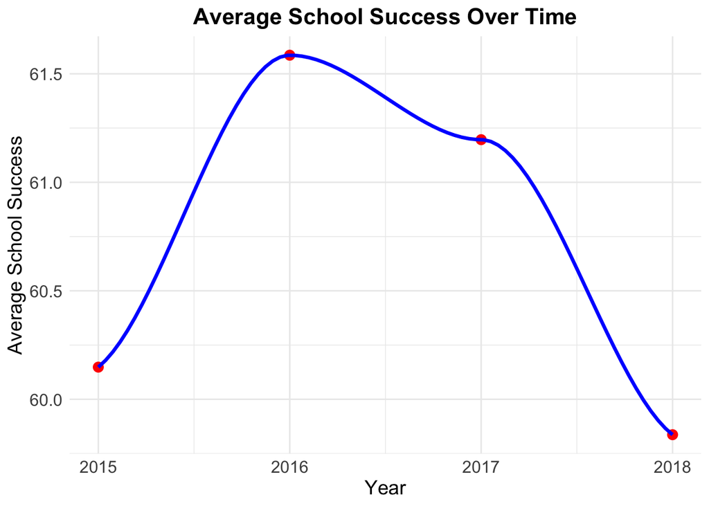

The figure highlights only subtle changes from 2015 to 2018, suggesting that the impact of the Crime Reform Act on school success was minimal. This trend does not strongly support the hypothesis that the policy significantly contributed to improvements in school success during this period.

## Crime Severity Index

The *Crime Severity Index* is a weighted measure designed to capture the impact of safety conditions within and around schools.

### Crime Severity Index Formula

$$\text{CSI} = \frac{10V + 5P + 3N + A}{S}$$

Where:

| Abbreviation | Description |
| --- | --- |
| CSI | Crime Severity Index |
| V | Violent Crimes |
| P | Property Crimes |
| N | Non-Criminal Incidents |
| A | Total Arrests |
| S | Total Students |

Each type of crime is assigned a weight based on its perceived severity, with violent crimes having the highest weight, followed by property crimes, and then non-criminal incidents. Arrest data, collected from within an eighth-mile radius around each school, is included to reflect neighborhood safety conditions.

This variable accounts for the dual influence of internal (on-campus) and external (neighborhood) safety on school environments. Safety conditions can significantly affect student well-being, attendance, parental involvement, and overall academic performance. Weighting crimes by severity ensures that the measure accurately reflects their differential impacts on the school community.

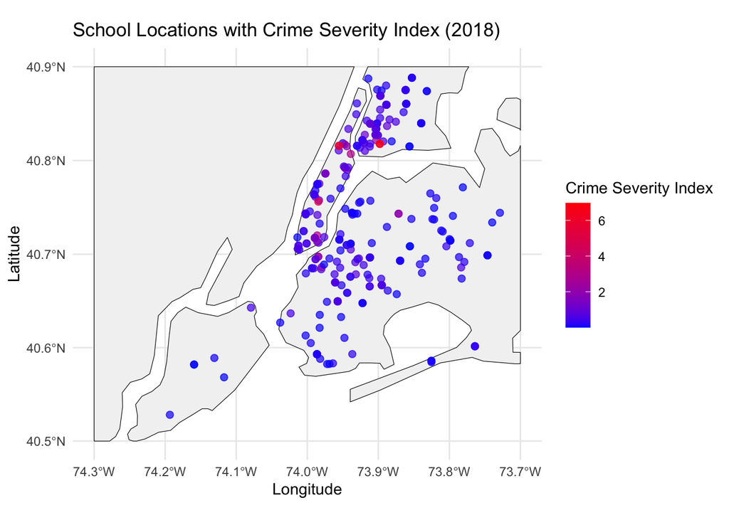

[interactive chart not shown]

The *Crime Severity Index* serves as a critical explanatory variable in this analysis. By examining its relationship with *School Success*, we can assess how safety conditions shape educational outcomes. Additionally, this variable provides insights into the effectiveness of policy interventions, such as the Crime Reform Act, in improving school environments.

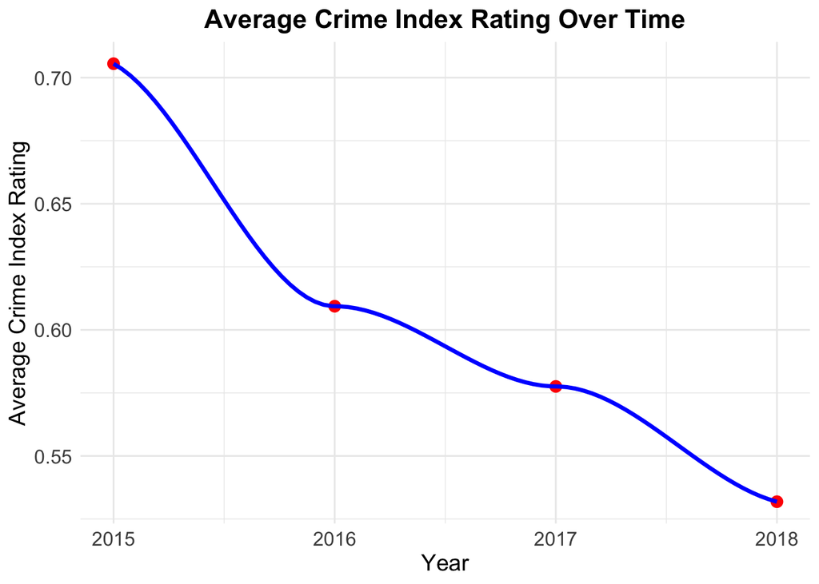

The Crime Index Rating decreased from 2015 to 2018, suggesting a potential correlation between the implementation of the Crime Reform Act and improved safety conditions. This trend indicates that the policy may have contributed to a reduction in crime severity during this period.

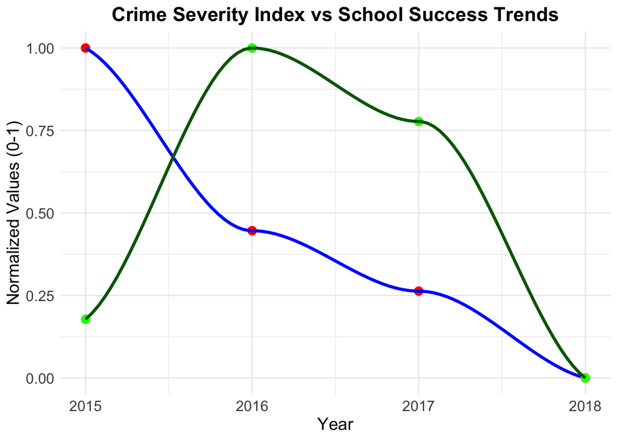

## Value per Square Foot

The variable *Value per Square Foot* measures the economic context of a school’s location by capturing the average property value per square foot of the school building and its surroundings. It is calculated as follows:

### Value per Square Foot Formula

$$\text{Value per Square Foot} = \frac{\text{Total Assessed
Value}}{\text{Building Area (sq. ft.)}}$$

To ensure reliability, only properties with building areas and valuations exceeding 10,000 square feet and 10,000 dollars, respectively, were included. This metric was merged with school directories using unique identifiers (BIN and BBL), ensuring an accurate linkage of property values to specific schools.

In this analysis, *Value per Square Foot* is included as a control variable. It accounts for economic disparities that may influence school resources and outcomes, isolating the effects of safety and attendance on academic performance. This metric also highlights how external economic factors interact with policy reforms to shape educational outcomes.

## Data Conclusion

These three variables — *School Success*, *Crime Severity Index*, and *Value per Square Foot* — capture key dimensions of school performance, safety, and economic context. Together, they enable a comprehensive exploration of how environmental and institutional factors influence educational outcomes and the effectiveness of policy interventions. By integrating these variables into a balanced panel dataset, this analysis provides actionable insights for improving school success in diverse settings.

Summary Statistics Table

| Variable | Mean | SD | Median | P10 | P90 |
| --- | --- | --- | --- | --- | --- |
| School | 60.6918049 | 10.5603505 | 58.9100100 | 49.0392720 | 75.949898 |
| Crime | 0.6060872 | 0.9009707 | 0.3198757 | 0.0420684 | 1.452681 |
| Value | 177.4011705 | 88.4212221 | 159.1125000 | 94.1829297 | 283.890865 |

The summary statistics reveal key insights. *School Success* averages highlight moderate performance but show large gaps between the 10th and 90th percentiles, indicating disparities. The *Crime Severity Index* varies widely, most likely reflecting significant safety issues in certain schools. *Value per Square Foot* is consistent for most schools but reveals economic disparities at the extremes.

# Model

## Model Estimation

Simple Regression: School Success on Crime Severity Index

| Term | Estimate | Std. Error | t Value | p Value | Significance |
| --- | --- | --- | --- | --- | --- |
| (Intercept) | 4.1535864 | 0.0068250 | 608.582772 | 0 | *** |
| crime_severity_index_log | -0.1177786 | 0.0126984 | -9.275068 | 0 | *** |

Significance levels: *** p < 0.001, ** p < 0.01, * p < 0.05

Pre Policy Regression: School Success on Crime Severity Index

| Term | Estimate | Std. Error | t Value | p Value | Significance |
| --- | --- | --- | --- | --- | --- |
| (Intercept) | 3.8417864 | 0.0765637 | 50.177653 | 0.00e+00 | *** |
| crime_severity_index_log | -0.1005403 | 0.0166066 | -6.054237 | 0.00e+00 | *** |
| value_per_sqft_log | 0.0617150 | 0.0149850 | 4.118467 | 4.38e-05 | *** |

Significance levels: *** p < 0.001, ** p < 0.01, * p < 0.05

Post Policy Regression: School Success on Crime Severity Index

| Term | Estimate | Std. Error | t Value | p Value | Significance |
| --- | --- | --- | --- | --- | --- |
| (Intercept) | 3.7945911 | 0.0804133 | 47.188582 | 0.0e+00 | *** |
| crime_severity_index_log | -0.1311804 | 0.0190759 | -6.876764 | 0.0e+00 | *** |
| value_per_sqft_log | 0.0697052 | 0.0154915 | 4.499562 | 8.2e-06 | *** |

Significance levels: *** p < 0.001, ** p < 0.01, * p < 0.05

Model 1: With Policy Reform

| Term | Estimate | Std. Error | Significance |
| --- | --- | --- | --- |
| crime_severity_index_log | -0.1118314 | 0.0139843 | *** |
| value_per_sqft_log | 0.0323441 | 0.0111540 | ** |
| policy_reform | -0.0077735 | 0.0106645 |  |
| crime_policy_interaction | -0.0353278 | 0.0052977 | *** |
| factor(Year)2016 | 0.0193136 | 0.0047251 | *** |
| factor(Year)2017 | 0.0304325 | 0.0031465 | *** |

F-statistic: 20.7046358920507  
Significance levels: *** p < 0.001, ** p < 0.01, * p < 0.05

Model 2: Without Policy Reform

Estimate

Std. Error

Significance

crime_severity_index_log

-0.1274012

0.0162022

***

value_per_sqft_log

0.0322095

0.0111065

factor(Year)2016

0.0187855

0.0047995

***

factor(Year)2017

0.0084916

0.0069339

factor(Year)2018

-0.0212284

0.0097495

F-statistic: 24.3593577564955

Significance levels: *** p < 0.001, ** p < 0.01, * p < 0.05

## Final Model

### SRF Model

$$\begin{multline}
\text{School_Success_log}_i =
-0.1274 \cdot \text{crime_severity_index_log}_i +
0.0322 \cdot \text{value_per_sqft_log}_i +
0.0188 \cdot \text{Year}_{2016} +
-0.0212 \cdot \text{Year}_{2018}
\end{multline}$$

## Analysis

The OLS estimations presented in tables 5, 6, and 7 provide a foundational understanding of the relationship between crime and academic success in New York City public schools. These results offer important preliminary insights, but could present potential endogeneity of crime variables—where factors such as school resources, neighborhood socioeconomic conditions, or unobserved elements of school climate could influence both academic outcomes and crime rates. The biases may undermine the causal interpretation of the estimated coefficients, particularly in a complex system like New York City’s educational landscape.

In this project, addressing endogeneity is particularly crucial because unaccounted-for variables, such as school-specific interventions or localized reforms, might be driving both crime severity and educational performance. For example, a school that experiences reduced crime rates may also benefit from policy changes, parental involvement, or increased funding, all of which could independently affect academic success. Without properly isolating these effects, the OLS estimates risk conflating correlation with causation.

The results in these tables emphasize the need for a more robust modeling approach, leading to the adoption of panel data models within the project. The panel model allows for the inclusion of time-invariant fixed effects to control for unobserved heterogeneity across schools, such as baseline differences in administration quality or community engagement. This transition not only strengthens the reliability of the analysis but also aligns with the project’s goal of evaluating the impacts of crime reform policies and broader socioeconomic dynamics on student outcomes.

The logarithmic transformation is applied to variables such as *School Success*, *Crime Severity Index*, and *Value per Square Foot* to handle non-linear relationships and provide interpretable results. By using logs, the model can assess the percentage change in *School Success* in response to a percentage change in predictors, such as crime severity or economic context. This transformation also stabilizes variance, allowing for a clearer relationship between variables.

The second model is preferable to the first because it omits the policy reform interaction term, simplifying the model and reducing potential multicollinearity. This allows for a sharper focus on the primary variables, *Crime Severity Index* and *Value per Square Foot*, and their direct effects on *School Success*. Without the interaction term, the model becomes more robust and interpretable while maintaining explanatory power.

# Conclusion

This research highlights the critical relationship between crime severity and academic success within the New York City public school system. The findings demonstrate a statistically significant association between the weighted Crime Severity Index (CSI) and school success, measured as the log of a composite indicator encompassing attendance and Regents exam scores. These results extend prior studies by emphasizing the role of neighborhood safety in shaping educational outcomes and suggest that interventions targeting community crime may have broader implications for academic equity.

These findings contribute to ongoing discussions about the importance of addressing systemic inequalities in education. Policymakers and educators should consider the interconnected nature of crime, socioeconomic conditions, and school quality when designing interventions to improve educational access and performance. Ultimately, addressing disparities in neighborhood safety and resources is essential for fostering environments where all students can thrive academically, regardless of their socioeconomic background.

# References

2010 - 2016 School Safety Report | NYC Open Data. *NYC Open Data*. https://data.cityofnewyork.us/Education/2010-2016-School-Safety-Report/qybk-bjjc/about_data. Accessed 8 Dec. 2024.

2013-2019 Attendance Results - School | NYC Open Data. *NYC Open Data*. https://data.cityofnewyork.us/Education/2013-2019-Attendance-Results-School/vww9-qguh/about_data. Accessed 8 Dec. 2024.

2014 - 2015 DOE High School Directory | NYC Open Data. *NYC Open Data*. https://data.cityofnewyork.us/Education/2014-2015-DOE-High-School-Directory/n3p6-zve2/about_data. Accessed 8 Dec. 2024.

2014-15 to 2017-19 NYC Regents Exam Results - Public | NYC Open Data. *NYC Open Data*. https://data.cityofnewyork.us/Education/2014-15-to-2017-19-NYC-Regents-Exam-Results-Public/bnea-fu3k/about_data. Accessed 8 Dec. 2024.

2016 - 2017 School Safety Report | NYC Open Data. *NYC Open Data*. https://data.cityofnewyork.us/Education/2016-2017-School-Safety-Report/rear-wh5i/about_data. Accessed 8 Dec. 2024.

2016 DOE High School Directory | NYC Open Data. *NYC Open Data*. https://data.cityofnewyork.us/Education/2016-DOE-High-School-Directory/7crd-d9xh/about_data. Accessed 8 Dec. 2024.

2017 - 2018 Schools NYPD Crime Data Report | NYC Open Data. *NYC Open Data*. https://data.cityofnewyork.us/Education/2017-2018-Schools-NYPD-Crime-Data-Report/kwvk-z7i9/about_data. Accessed 8 Dec. 2024.

2017 DOE High School Directory | NYC Open Data. *NYC Open Data*. https://data.cityofnewyork.us/Education/2017-DOE-High-School-Directory/s3k6-pzi2/about_data. Accessed 21 Oct. 2024.

2018 DOE High School Directory | NYC Open Data. *NYC Open Data*. https://data.cityofnewyork.us/Education/2018-DOE-High-School-Directory/vw9i-7mzq/about_data. Accessed 8 Dec. 2024.

Baron, E. Jason, et al. ‘Public School Funding, School Quality, and Adult Crime.’ *National Bureau of Economic Research*, Working Paper 29855, Mar. 2022. https://doi.org/10.3386/w29855.

Deming, David J. ‘Better Schools, Less Crime?’ *The Quarterly Journal of Economics*, vol. 126, no. 4, 2011, pp. 2063–115.

Fryer Jr., Roland G., and Lawrence F. Katz. ‘Achieving Escape Velocity: Neighborhood and School Interventions to Reduce Persistent Inequality.’ *American Economic Review*, vol. 103, no. 3, May 2013, pp. 232–37. https://doi.org/10.1257/aer.103.3.232.

NYPD Arrests Data (Historic) | NYC Open Data. *NYC Open Data*. https://data.cityofnewyork.us/Public-Safety/NYPD-Arrests-Data-Historic-/8h9b-rp9u/about_data. Accessed 8 Dec. 2024.

Primary Land Use Tax Lot Output (PLUTO) | NYC Open Data. *NYC Open Data*. https://data.cityofnewyork.us/City-Government/Primary-Land-Use-Tax-Lot-Output-PLUTO-/64uk-42ks/about_data. Accessed 8 Dec. 2024.

Property Valuation and Assessment Data | NYC Open Data. *NYC Open Data*. https://data.cityofnewyork.us/City-Government/Property-Valuation-and-Assessment-Data/yjxr-fw8i/about_data. Accessed 8 Dec. 2024.

Ruiz, Linda D., et al. ‘The Role of Neighborhood Context and School Climate in School-Level Academic Achievement.’ *American Journal of Community Psychology*, vol. 61, no. 3–4, 2018, pp. 296–309. https://doi.org/10.1002/ajcp.12234.